# icvs_first_analyses

## Procedure

The relationship between country-level inequality and the consumption of security products will be tested using a multilevel linear regression. This analysis will be accomplished using a combination of three archival datasets.

Firstly, indicators of security consumption have been accessed from the International Crime Victimization survey (ICVS; REF), which is an accumulation of standardized sample surveys to look at householders’ experiences with crime, policing, crime prevention and feelings of unsafety. Although it does not consist of longitudinal observations, the ICVS has been distributed across five phases over fifteen years (1989, 1992, 1996, 2000, 2005), totaling 300,000 people and 78 different countries (Data Archiving and Networked Services, n.d.). For the purposes of this study, it is most notable that this survey contains items such as respondents’ adopted measures to protect themselves against burglary.

Secondly, nation-level inequality in disposable income was accessed through the Standardized World Income Inequality Database (SWIID; REF). The SWIID has been designed to maximize the comparability of income inequality data while maintaining the widest possible coverage across countries and over time. As a result, the gini coefficients are accompanied by standard errors to reflect uncertainty in the estimates.

Lastly, countries’ expenditure-side real GDP was retrieved from the Penn World Table, version 10.0 (PWT; REF). The selected GDP values are adjusted for Purchasing Power Parity, “to compare relative living standards across countries at a single point in time” (https://www.rug.nl/ggdc/productivity/pwt/?lang=en). Nations’ GDP values were divided by their population sizes to yield a per-capita GDP value, which will be used for these analysis.

Although the above datasets extend across multiple years, the current analysis will be limited to observations across 2004-2006. Imposing this restriction allows for a sufficient number of countries, combined with relative recency of data. After a conservative exclusion process for missing data, survey sweeps conducted across 2004-6 yielded 31 countries with 85,085 participants, with a minimum of 790 participants per country. An exclusion strategy maximizing the number of variables yields 27 countries, and 48,671 participants.

# Analysis procedure

If the assumptions underlying a multilevel regression hold in this dataset, the analysis will be conducted using maximum likelihood estimates (MLE) in r package lme4 (REF). Despite the possibility of nonnormal data, the large sample size in this study will yield similar variance estimates to REML estimation.

Given that the SWIID is presented in a list of 100 different dataframes, the analysis will firstly be conducted on each dataframe, with the results stored separately.

```r
# Estimate model
# m1 <- icvs_joined %>%
#   map(~ lme4::lmer(num_victim_5yr ~ gini_2004_6_cent + gdppc_2004_6_cent +
#                      age_cent + employed + male + (1 | country),data = .x, REML=FALSE))


m1_sample <- lme4::lmer(num_victim_5yr ~ gini_2004_6_cent + gdppc_2004_6_cent +
                     age_cent + employed + male + (1 | country),data = join_sample, REML=FALSE)


# Both packages use Lattice as the backend, but nlme has some nice features like groupedData() and lmList() that are lacking in lme4 (IMO). From a practical perspective, the two most important criteria seem, however, that

# https://lme4.r-forge.r-project.org/book/

#    lme4 extends nlme with other link functions: in nlme, you cannot fit outcomes whose distribution is not gaussian, lme4 can be used to fit mixed-effects logistic regression, for example.
#    in nlme, it is possible to specify the variance-covariance matrix for the random effects (e.g. an AR(1)); it is not possible in lme4.

#Now, lme4 can easily handle very huge number of random effects (hence, number of individuals in a given study) thanks to its C part and the use of sparse matrices. The nlme package has somewhat been superseded by lme4 so I won't expect people spending much time developing add-ons on top of nlme. Personally, when I have a continuous response in my model, I tend to use both packages, but I'm now versed to the lme4 way for fitting GLMM.

# nlme let's you specify variance-covariance structures for the residuals (i.e. spatial or temporal autocorrelation or heteroskedasticity), lme4 doesn't

# https://stats.stackexchange.com/questions/5344/how-to-choose-nlme-or-lme4-r-library-for-mixed-effects-models
# lmeg or nlme?
#nlme is the very large tool box, including a TIG welder to make any tools you need.

# brms: Bayesian Regression Models using 'Stan'
# https://cran.r-project.org/web/packages/brms/index.html
```

Each of these 100 dataframes will then be subjected to 100 simulations, yielding vectors of 10,000 estimates. The means and distributions of these vectors will yield the coefficient and standard error values, respectively.

“We could now use Rubin’s (1987) rules to calculate the mean and standard error for each fixed effect estimate across these 100 sets of results (these rules are implemented in the package mitools (Lumley 2014) and others), but instead we will use simulation. Using sim from the arm package (Gelman and Su 2015), we generate the distribution of fixed-effects estimates in the results both for each dataframe and across the 100 dataframes.”

Then we will use these distributions to calculate estimates and standard errors for each fixed effect, putting them in a tidy data frame like that achieved by using broom::tidy() (Robinson 2016).

```r
# Generate a tidy dataframe of results (cf. broom::tidy())

# m1_tidy <- tibble(term = names(m1_sims),
# estimate = summarise_all(m1_sims, list(mean)) %>%
# t() %>%
# as.vector(),
# std.error = m1_sims %>%
# summarise_all(list(sd)) %>%
# t() %>%
# as.vector())




# transmute(country = countrycode(S003,
# origin = "iso3n",
# destination = "country.name"),
# year = as.numeric(S020),
# religiosity = ifelse(F063>0, F063, NA),
#
# male = ifelse(X001>0, as.numeric(X001 == 1), NA),
# educ = ifelse(X025>0, X025, NA),
# age = ifelse(X003>0, X003, NA)) %>%
# filter(complete.cases(.)) %>%
# left_join(pwt91_gdppc, by = c("country", "year"))
#
# m1_tidy

summary(m1_sample)
```

```
## Linear mixed model fit by maximum likelihood  ['lmerMod']
## Formula: num_victim_5yr ~ gini_2004_6_cent + gdppc_2004_6_cent + age_cent +
##     employed + male + (1 | country)
##    Data: join_sample
##
##       AIC       BIC    logLik  deviance  df.resid
##  212766.5  212841.3 -106375.2  212750.5     85077
##
## Scaled residuals:
##     Min      1Q  Median      3Q     Max
## -1.5312 -0.6554 -0.4100  0.5389  7.6821
##
## Random effects:
##  Groups   Name        Variance Std.Dev.
##  country  (Intercept) 0.01964  0.1401
##  Residual             0.71252  0.8441
## Number of obs: 85085, groups:  country, 31
##
## Fixed effects:
##                     Estimate Std. Error t value
## (Intercept)        5.515e-01  2.571e-02  21.449
## gini_2004_6_cent   1.025e-02  3.655e-03   2.805
## gdppc_2004_6_cent -2.563e-07  1.950e-06  -0.131
## age_cent          -6.381e-03  1.817e-04 -35.120
## employed1          3.627e-02  6.141e-03   5.906
## male1             -4.727e-03  5.970e-03  -0.792
##
## Correlation of Fixed Effects:
##             (Intr) gn_2004_6_ gd_2004_6_ ag_cnt emply1
## gn_2004_6_c  0.057
## gdp_2004_6_  0.058  0.589
## age_cent    -0.036  0.020      0.000
## employed1   -0.108  0.009     -0.004      0.250
## male1       -0.076 -0.004     -0.001     -0.020 -0.169
## fit warnings:
## Some predictor variables are on very different scales: consider rescaling
```

# reporting effects and models

there is much to be gained when researchers follow a standardized way of reporting effect sizes (Lumley et al., 2002).

# Assumption checks and and contingencies

**1. Linearity**

- **Check:** Scatterplots
- **Fix:** add polynomials until adequate fit to linear function is obtained

Nonlinearity does not seem to be a major issue in the data. Especially with a small sample, adding polynomials seems more likely to risk overfitting the data. If anything, these charts suggest that these trends might be largely driven by a few influential observations.

```
##      Min.   1st Qu.    Median      Mean   3rd Qu.      Max.
## 0.000e+00 1.167e-05 2.427e-05 6.140e-05 4.678e-05 5.383e-03
```

```
##      Min.   1st Qu.    Median      Mean   3rd Qu.      Max.
## 0.0000000 0.0009272 0.0077158 0.0649877 0.0298809 0.7044434
```

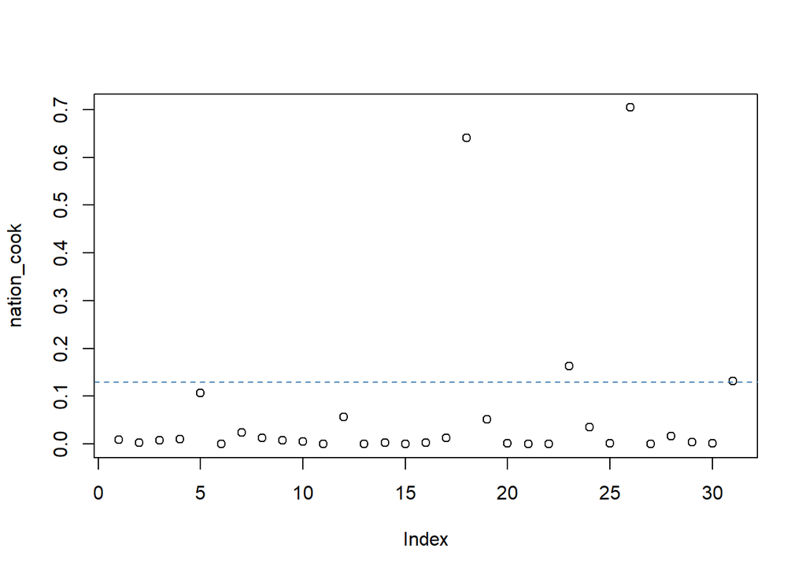

```
##      Min.   1st Qu.    Median      Mean   3rd Qu.      Max.
## 0.0000000 0.0006056 0.0050926 0.0509058 0.0374520 0.6028790
```

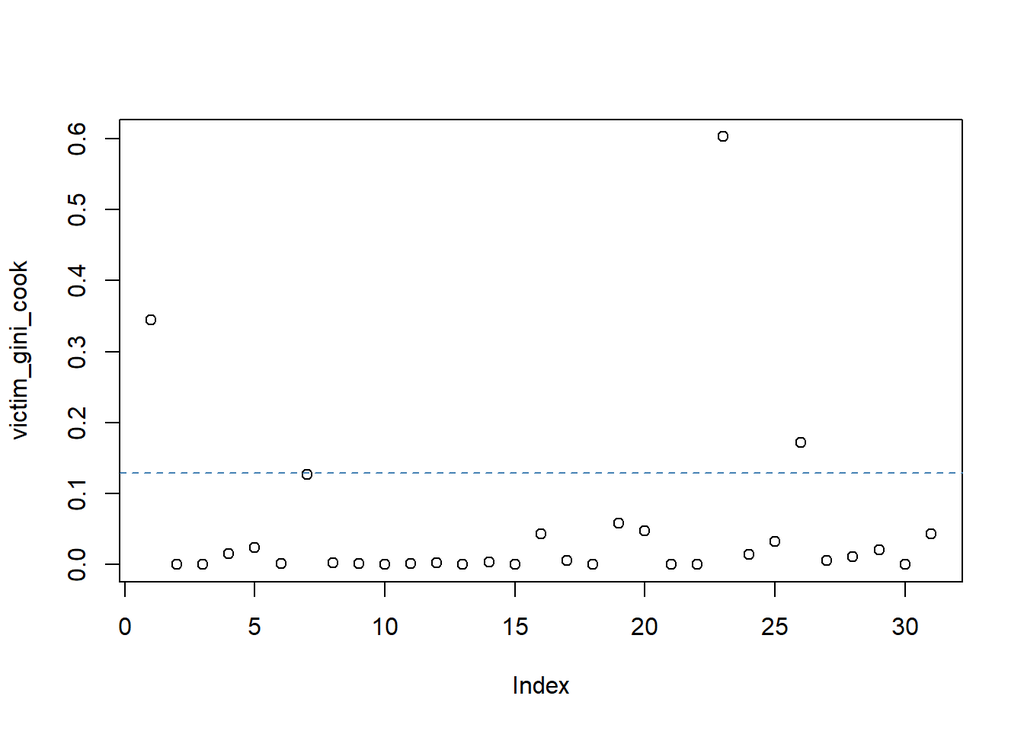

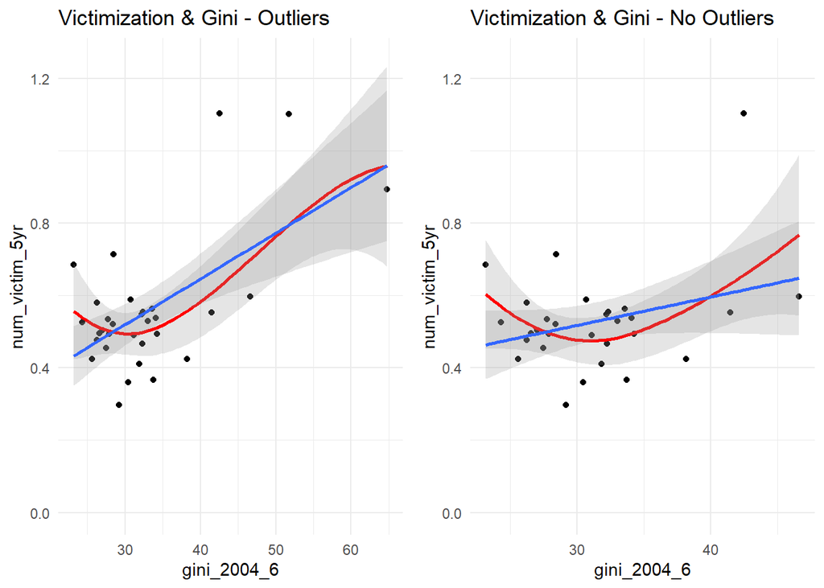

```
##      Min.   1st Qu.    Median      Mean   3rd Qu.      Max.
## 0.0000002 0.0008148 0.0052600 0.0541196 0.0327987 0.5136671
```

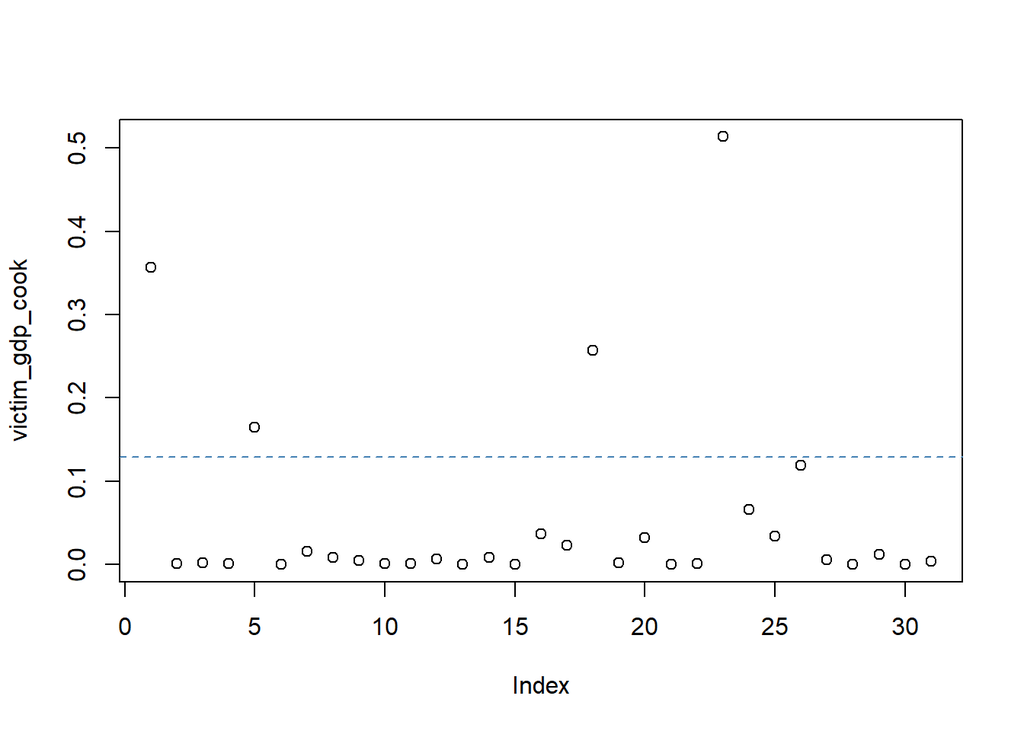

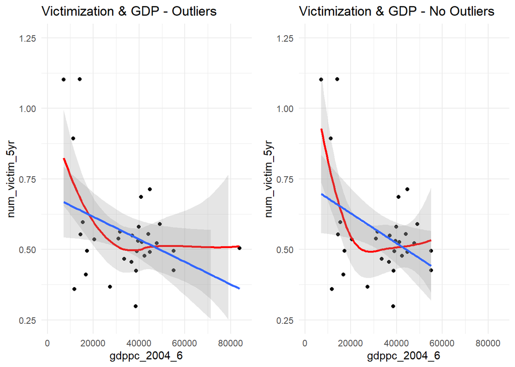

However, the cooks distance values are all well under 1. Importantly, this is the same for the nation-level variables; they have a smaller sample size - and are thus the more susceptible to influential observations.

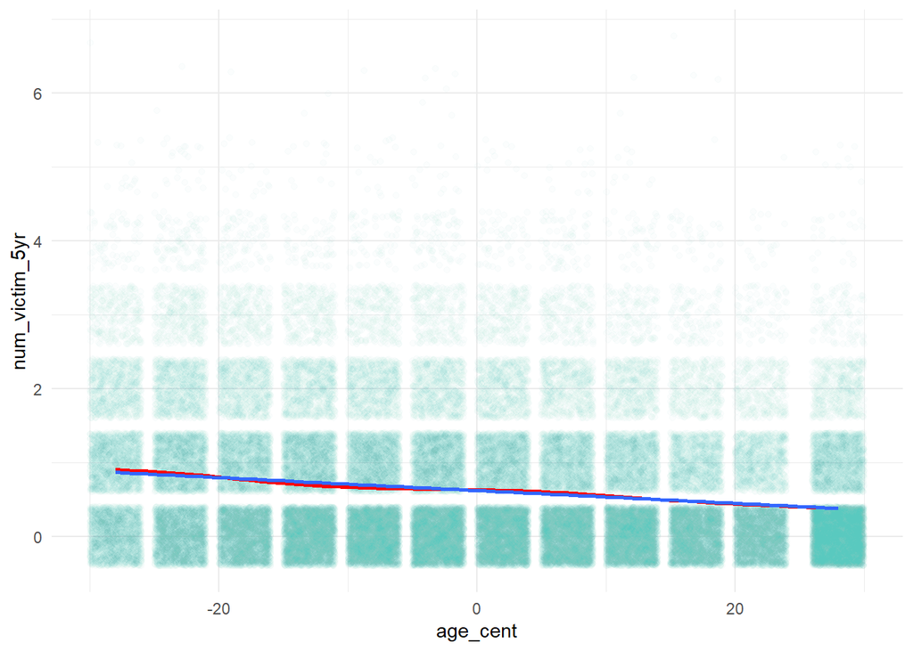

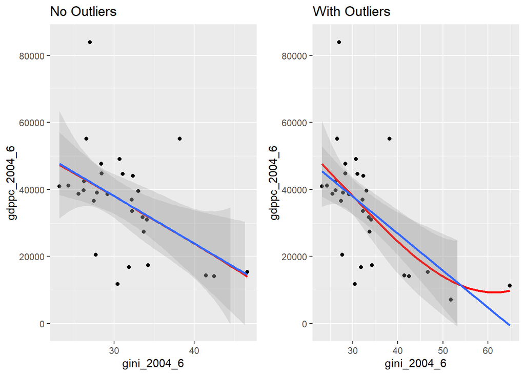

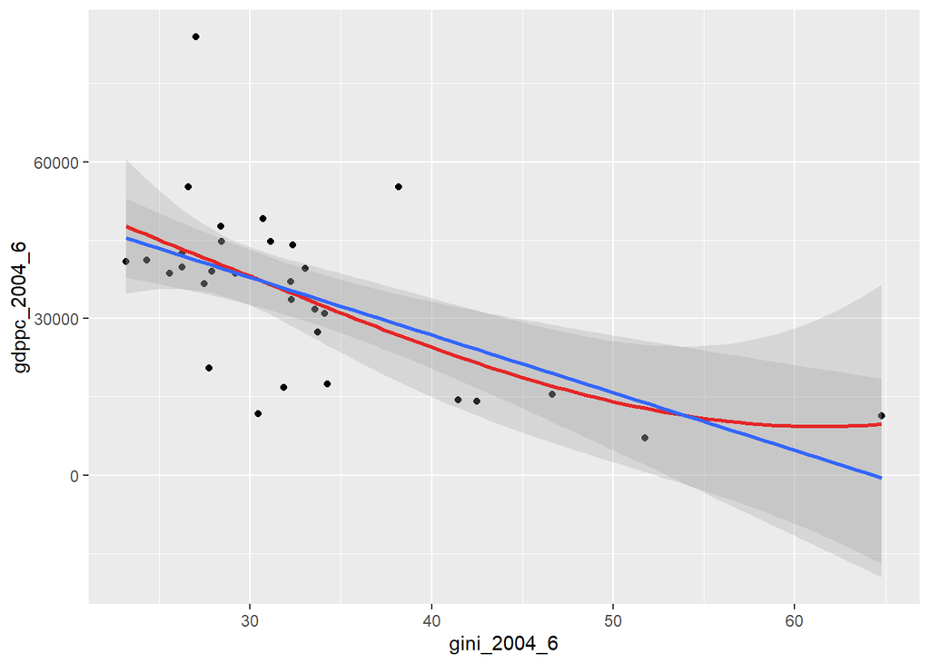

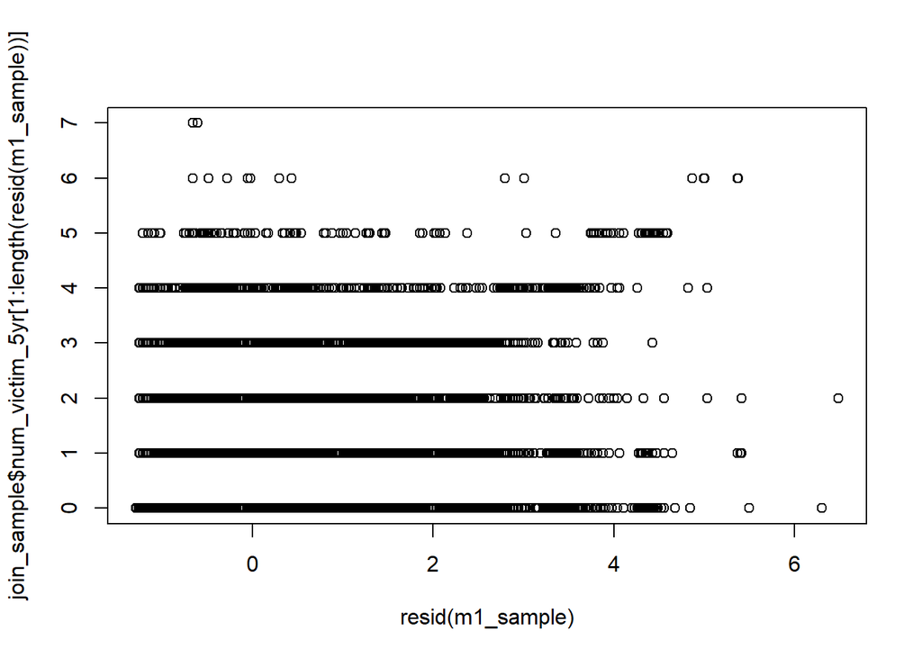

**2. Normality in residuals**

- **Check**: QQplots (The Normal Probability Plot method.)
  - Levene’s test - this is more robust to departures from normality than Bartlett’s test. It is in the car package.
  - Fligner-Killeen test - this is a non-parametric test which is very robust against departures from normality.
- **NO treatment:** Lumley, Diehr, Emerson, & Chen (2002) provided simulation evidence that linear regressions conducted on large samples are robust to departures from normality. With at least 500 observations, they found that linear regression can be conducted with negligible impact on Type I errors. Likewise, Knief & Forstmeier (2021) found that for anything other than very small sample sizes, “p-values from Gaussian models are highly robust to even extreme violation of the normality assumption and can be trusted, except when involving X and Y distributions with extreme outliers (p. ??). Likewise,”for N = 1000, power was essentially unaffected by the distribution of Y and X."

Finally, the authors found a Gaussian error distribution to be far more robust to violations of its assumptions than Poisson and Binomial distributions. Initially, a binomial or poisson process seems to better describe the distribution of this study’s dependent variable (both for the proposed and presented analyses). However, these variables likely violate the assumption of event independence, where one event does not affect the likelihood of a subsequent event. For instance, in the case of security consumption, the psychological and material impacts of buying a security product (e.g., feelings of safety, reduced budget), can plausibly impact a consumers’ decision to purchase further security goods. Given the potential for heavy bias in poisson and negative binomial models, a gaussian error structure’s comparative robustness appears to make a (violated) assumption of normality be the most appropriate choice.

> Moreover, we worry that sophisticated methods may allow presenting nearly anything as statistically significant (Simmons et al., 2011) because complex methods will only rarely be questioned by reviewers.

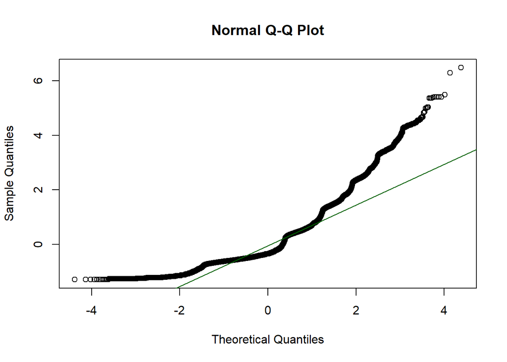

```r
qqnorm(resid(m1_sample))
qqline(resid(m1_sample), col = "darkgreen")
```

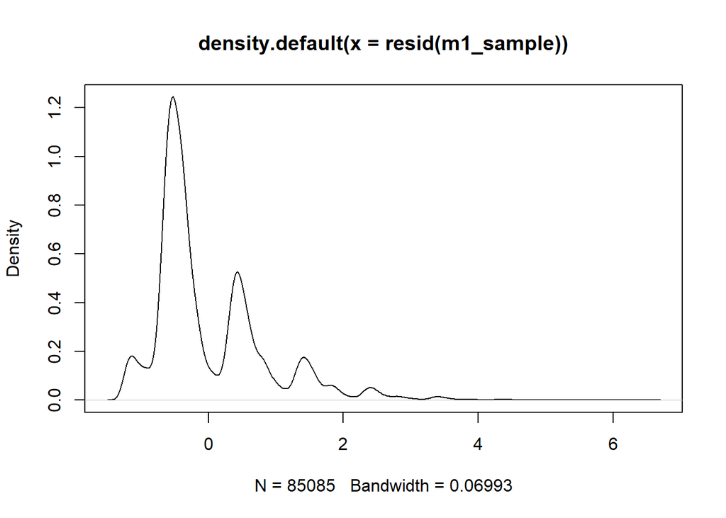

```r
plot(density(resid(m1_sample)))
```

```r
moments::skewness(resid(m1_sample))
```

```
## [1] 1.479687
```

```r
moments::kurtosis(resid(m1_sample))
```

```
## [1] 5.723795
```

Indeed, this is dependent variable is definitely not normal, with a skewness of 1.48, and a kurtosis of *5.72*

With high sample sizes, their analyses found that even dramatic violations of normality assumptions (gaussian and binomial distributions) had no impact on Type I errors

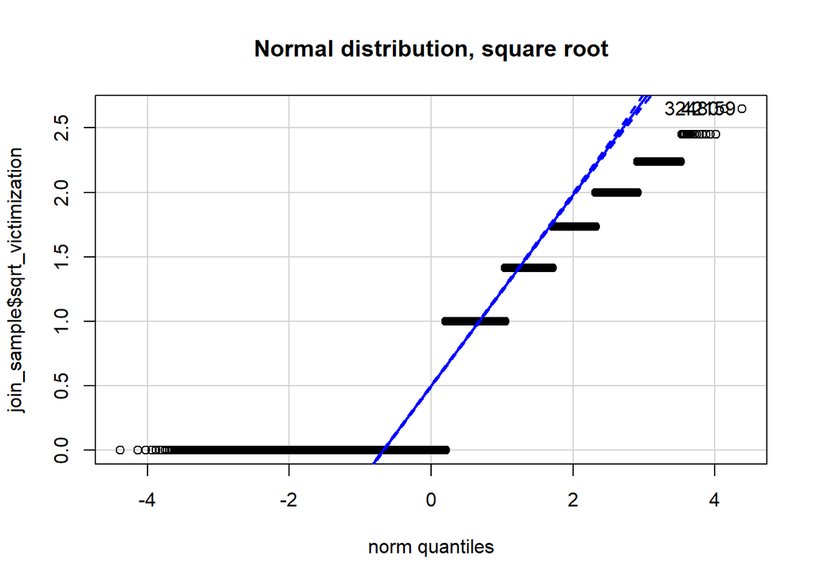

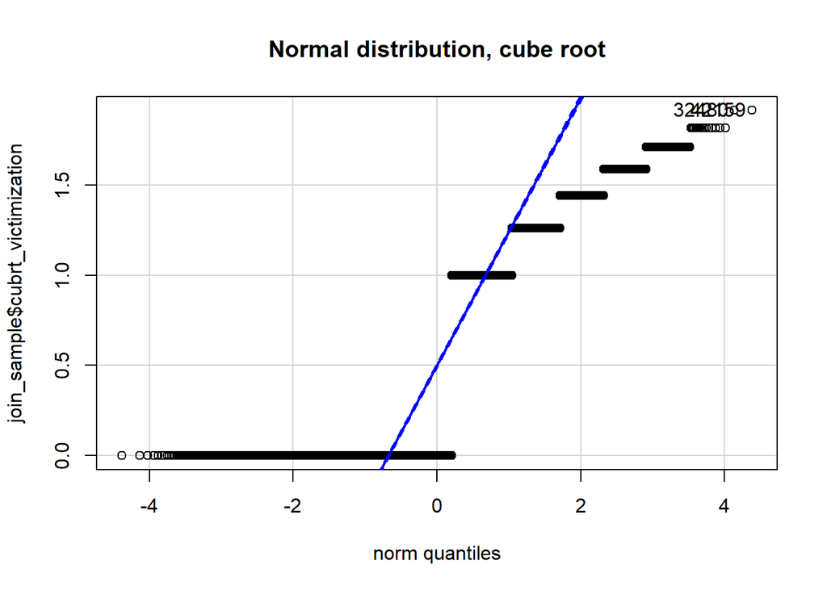

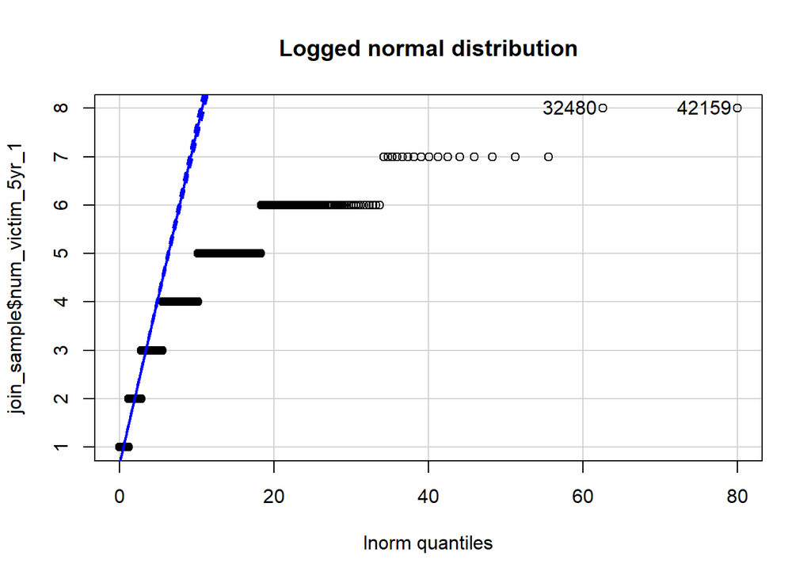

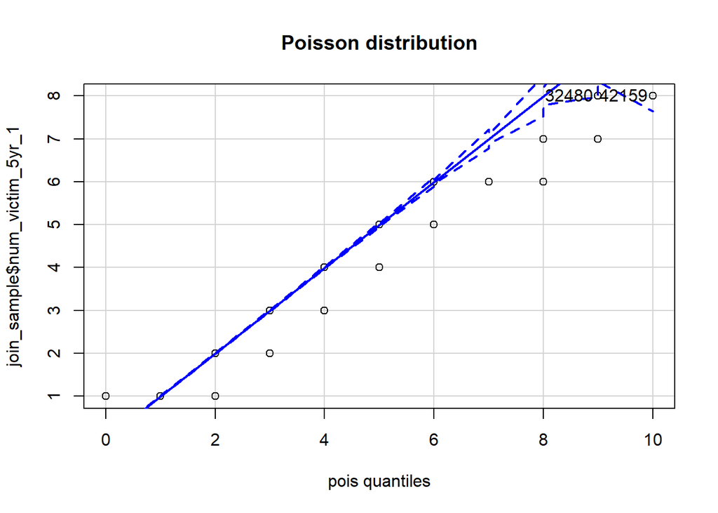

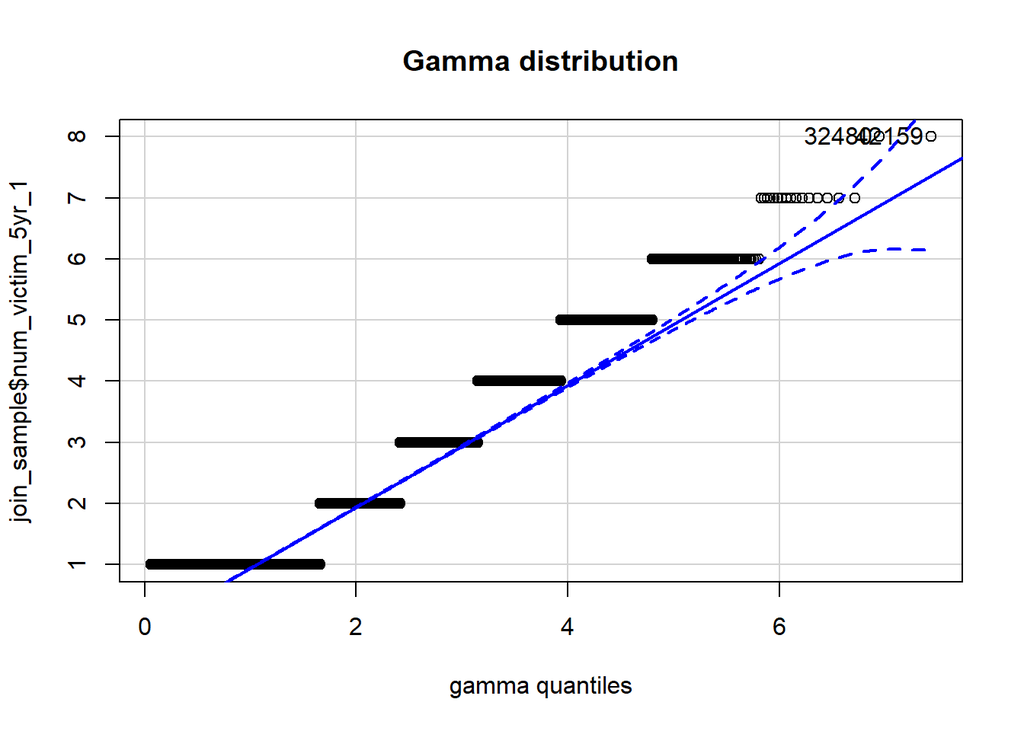

**3. Multicolinnearity**

- **Check**: VIF/tolerances
- **Fix** remove values >= 5

```r
car::vif(m1_sample) # display VIF values
```

```
##  gini_2004_6_cent gdppc_2004_6_cent          age_cent          employed
##          1.531991          1.531395          1.067757          1.098260
##              male
##          1.029947
```

4. HETEROSCEDASTICITY
- **Check**: Plot residuals vs predicted values, and residuals versus independent variables
  - Others: Breush-Pagan test and the NCV test, levene’s test
- **Fix** with Box-Cox transformation of DV; caret::BoxCoxTrans(yvar), log transformation of DV
- boxcoxmix packag

> There is a two-parameter version of the Box-Cox transformation that allows a shift before transformation:usual Box-Cox transformation sets λ2=0. One common choice with the two-parameter version is λ1=0 and λ2=1 which has the neat property of mapping zero to zero. There is even an R function for this: log1p(). More generally, both parameters can be estimated. In R, the boxcox.fit() function in package geoR will fit the parameters.
> - Inverse hyperbolic sine (IHS) transformation, mixture models (https://robjhyndman.com/hyndsight/transformations/) Other options:
> - we want to obtain heteroskedasticity robust standard errors and their corresponding t values. In R the function coeftest from the lmtest package can be used in combination with the function vcovHC from the sandwich package to do this.

https://stackoverflow.com/questions/48479984/r-mixed-model-with-heteroscedastic-data-only-lm-function-works

> The sandwich package is not limited to lm/glm only but it is in principle object-oriented, see vignette(“sandwich-OOP”, package = “sandwich”) (also published as doi:10.18637/jss.v016.i09.

> There are suitable methods for a wide variety of packages/models but not for nlme or lme4. The reason is that it’s not so obvious for which mixed-effects models the usual sandwich trick actually works. (Disclaimer: But I’m no expert in mixed-effects modeling.)

> However, for lme4 there is a relatively new package called merDeriv (https://CRAN.R-project.org/package=merDeriv) that supplies estfun and bread methods so that sandwich covariances can be computed for lmer output etc. There is also a working paper associated with that package: https://arxiv.org/abs/1612.04911
- https://www.r-econometrics.com/methods/hcrobusterrors/

> For a heteroskedasticity robust F test we perform a Wald test using the waldtest function, which is also contained in the lmtest package. It can be used in a similar way as the anova function, i.e., it uses the output of the restricted and unrestricted model and the robust variance-covariance matrix as argument vcov. Based on the variance-covariance matrix of the unrestriced model we, again, calculate White standard errors.

knief and Forstmeier, 2021 > Most elegantly,heteroscedasticity can be modeled directly, for instance by using the “weights” argument in lme (see Pinheiro & Bates, 2000, p. 214), which also enables us to test directly whether allowing for heteroscedasticity increases the fit of the model significantly. Similarly, heteroscedasticity-consistent standard errors could be estimated (Hayes & Cai, 2007). For more advice on handling heteroscedasticity, see McGuinness (2002).

> we did not cover collinearity between predictors or the distribution of random effects, but others have dealt with these aspects before (Freckleton, 2011; Schielzeth et al., 2020).

```r
levene_data<- join_sample[1:length(resid(m1_sample)),]

levene_data$model_res<- residuals(m1_sample)
levene_data$model_res_abs <-abs(levene_data$model_res) #creates a new column with the absolute value of the residuals
levene_data$model_res_abs2 <- levene_data$model_res_abs^2 #squares the absolute values of the residuals to provide the more robust estimate
levene_m1 <- lm(model_res_abs2 ~ country, data=levene_data) #ANOVA of the squared residuals
anova(levene_m1) #displays the results
```

```
## Analysis of Variance Table
##
## Response: model_res_abs2
##              Df Sum Sq Mean Sq F value    Pr(>F)
## country      30   3525 117.513   49.88 < 2.2e-16 ***
## Residuals 85054 200379   2.356
## ---
## Signif. codes:  0 '***' 0.001 '**' 0.01 '*' 0.05 '.' 0.1 ' ' 1
```

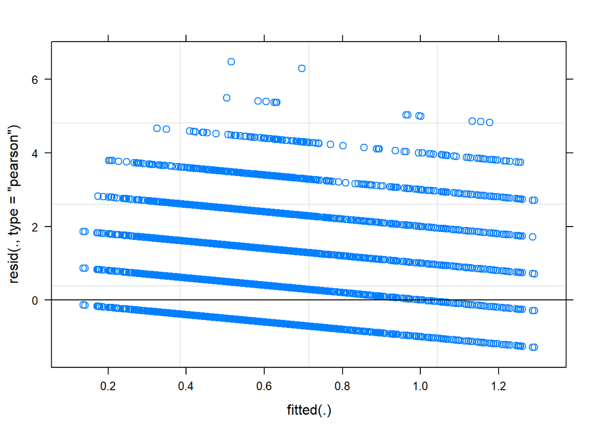

```r
# par(mfrow=c(2,2))

# plot(m1_sample, which = 1)

plot(m1_sample, resid(., type = "pearson") ~ fitted(.), abline = 0)
```

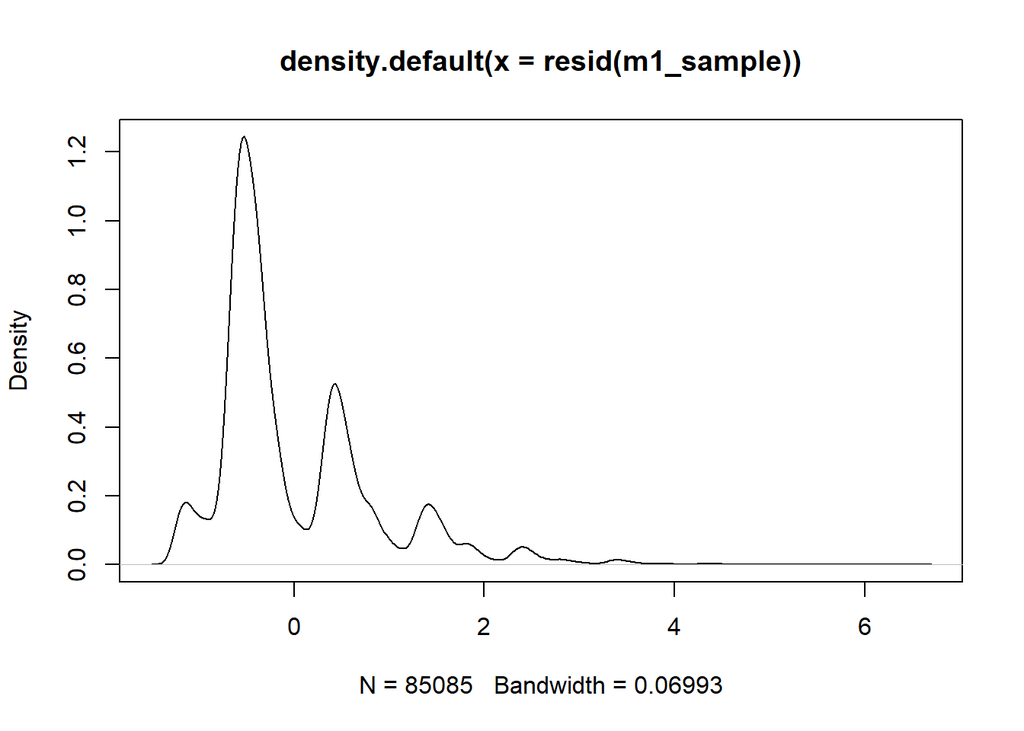

```r
plot(density(resid(m1_sample)))
```

```r
# https://www.r-econometrics.com/methods/hcrobusterrors/
# obtain heteroskedasticity robust standard errors and their corresponding t values. - no applicable method for 'estfun' applied to an object of class "c('lmerMod', 'merMod')"
# lmtest::coeftest(m1_sample, vcov = sandwich::vcovHC(m1_sample, type = "HC0"))

# Breush Pagan Test - doesn't seem to work for lmer models    https://www.r-bloggers.com/2016/01/how-to-detect-heteroscedasticity-and-rectify-it/
# lmtest::bptest(m1_sample)

# NCV test - definitely doesn't work for lmer
# car::ncvTest(m1_sample)

#varPower() might have something to do with improving homoscedasticity

# So I like to use heteroscedastic-consistent covariance matrices. This paper explains it well. The sandwich and lmtest packages are great. Here is a good explanation how to do it for a indpendent design in R with lm(y ~ x).
# https://stackoverflow.com/questions/48479984/r-mixed-model-with-heteroscedastic-data-only-lm-function-works
```

```r
# 1. linearity :DV/IV


# 2. HOMOSCEDASTICITY: the variance of errors is the same across all levels of the IV


#     Bartlett’s test - If the data is normally distributed, this is the best test to use. It is sensitive to data which is not non-normally distribution; it is more likely to return a “false positive” when the data is non-normal.

#
#
# 3. normality
#QQ plots # S3 method for lm
# qqPlot(m1_sample, xlab=paste(distribution, "Quantiles"),
#     ylab=paste("Studentized Residuals(",
#                 deparse(substitute(m1_sample)), ")", sep=""),
#     main=NULL, distribution=c("t", "norm"),
#     line=c("robust", "quartiles", "none"), las=par("las"),
#     simulate=TRUE, envelope=TRUE,  reps=100,
#     col=carPalette()[1], col.lines=carPalette()[2], lwd=2, pch=1, cex=par("cex"),
#     id=TRUE, grid=TRUE, ...)
#
# qqPlot(m1_sample)

#  independent residuals

# ggplot(m1_sample, aes(sample=.resid)) +
#     stat_qq()

# random coefficients are normally distributed in overall model

# reliability (of measurement)

# residuals are independent (Durbin-Watson)

# Multivariate Normality values of the residuals are normally distributed. (P-P plot)

# multicollinearity
```

> “Importantly, the robustness of regression methods to deviations from normality of the regression errors e does not only depend on sample size, but also on the distribution of the predictor X (Box & Watson, 1962; Mardia, 1971). Specifically, when the predictor variable X contains a single outlier, then it is possible that the case coincides with an outlier in Y, creating an extreme observation with high leverage on the regression line. This is the only case where statistical significance gets seriously misestimated based on the assumption of Gaussian errors in Y which is violated by the outlier in Y. This problem has been widely recognized (Ali & Sharma, 1996; Box&Watson, 1962; Miller, 1986; Osborne &Waters, 2002; Ramsey & Schafer, 2013; Zuur et al., 2010) leading to the conclusion that Gaussian models are robust as long as there are no outliers that occur in X and Y simultaneously.”

Knief & Forstmeier, 2021

> Poisson distribution - lambdas specify variance and mean of the distribution (doesn’t have to be an integer)

> We have shown that Poisson models yielded heavily biased type I error rates (at α = 0.05) in either direction ranging from 0 to as high as 0.55 when their distribution assumption is violated (Fig. 3 right column, Fig. S7).

> Moreover, we worry that sophisticated methods may allow presenting nearly anything as statistically significant (Simmons et al., 2011) because complex methods will only rarely be questioned by reviewers.

poisson assumptions * rate at which events occur is constant * occurence of one event does not affect occurence of a subsequent event

Probability Mass Function (PMF) - how likely a given value is

cumulative distribution function - all of the likelihoods of values up to and including the designated value

GEE: GENERALIZED LINEAR MODELS FOR DEPENDENT DATA (https://cehs-research.github.io/eBook_multilevel/gee-count-outcome-epilepsy.html) Match Poisson Regresssion (GLM)

restricted maximum likelihood (REML)

Thus REML, by accounting for the loss in degrees of freedom from estimating the fixed effects, provides an unbiased estimate of variance components, while ML estimators for variance components are biased under assumptions of normality, since they use estimated fixed effects rather than the true values.

lmeresampler provides an easy way to bootstrap nested linear-mixed effects models using either the parametric, residual, cases, CGR (semi-parametric), or random effects block (REB) bootstrap fit using either lme4 or nlme. The output from lmeresampler is an lmeresamp http://aloy.github.io/lmeresampler/

bootMer

https://www.juliapilowsky.com/2018/10/19/a-practical-guide-to-mixed-models-in-r/ Semi-parametric multilevel modeling (Tihomir Asparouhov)

Probably the advice on this site will be to start with what kind of data your dependent variable is, and then choose an appropriate glm or regression approach. That is, if your dv is count, perhaps Poisson or negative binomial regression. If your dv is concentration, perhaps gamma regression. –

Note that the negative binomial and gamma distributions can only handle positive numbers, and the Poisson distribution can only handle positive whole numbers

# Limitations

The most notable weakness is that this is data from WEIRD countries. Other, less WEIRD countries (e.g., phillipines, nigeria, india) are better represented throughout sweeps 2 to 4